# Atividade 7/7 - Diferenças em Diferenças (DiD)

Raphael Vieira dos Santos - matrícula: 190152974

Atividade 7/7 da disciplina **Laboratório de Econometria**, professor **Rafael Terra**, ofertada no semestre 2023/2.

## Situação Problema

Considere que o efeito do tratamento de um programa de distribuição de material didático à escolas públicas realizado em 2006 sobre a proficiência média das escolas em leitura e matemática se baseie na seguinte relação:

> proficiência_it = α + β1 * (grupo_tratado_i) * (d.2007_t) + β2 * (grupo_tratado_i) + β3 * (d.2007_i) + ε_i

Em que a variável `grupo_tratado` é uma dummy (variável binária, 0 ou 1) de escolas tratadas independentemente do ano. A variável `d.2007` é a variável dummy que indica o ano de 2007 (igual a 0 caso contrário), e a variável tratamento é uma dummy de interação entre as duas variáveis anteriores. Use o arquivo `banco_diff_diff.dta`, que está anexado à tarefa.

- **Passo 1:** Estime por OLS e interprete os coeficientes dos efeitos do tratamento sobre as proficiências de leitura e matemática. O programa foi efetivo?
- **Passo 2:** Informe a inclinação dos grupos de escolas tratadas e de controle e seus interceptos.
- **Passo 3:** Estime o seguinte modelo por efeitos fixos:

> proficiência_it = α + β1 * (tratamento_it) + β3 * (d.2007_t) + β2_i + ε_i

*Dica:* Use a função `plm[, type=“within”]` e compare os coeficientes com o modelo estimado na primeira equação. Existe alguma diferença entre os dois procedimentos?

- **Passo 4:** Se utilizássemos o método de primeiras diferenças obteríamos resultados diferentes?
- **Passo 5:** Suponha que você tivesse dados para o ano de 2003. Se adicionássemos os dados desse ano ao nosso banco e na primeira equação inseríssemos uma dummy para o ano de 2005 e a interação desta com grupo_tratado_i, qual seria a interpretação de um coeficiente `β0 = 10` com erro-padrão, s.e.`(β) = 3`?

## Abordagem DiD e Métodos de Estimação para Dados em Painel

A abordagem de `Diferenças em Diferenças (DiD)` é uma ferramenta poderosa na análise de impacto de intervenções, especialmente em estudos de painel. No contexto deste trabalho, o DiD compara as mudanças médias ao longo do tempo entre um grupo tratado e um grupo de controle, proporcionando uma estimativa do efeito causal da intervenção. A principal vantagem do DiD é controlar para fatores temporais não observados que afetam ambos os grupos, permitindo uma inferência mais robusta sobre o impacto do tratamento.

A estimação por `Mínimos Quadrados Ordinários (OLS)` é uma técnica fundamental para análises de regressão linear. No caso deste estudo, OLS foi utilizado para estimar a relação entre as variáveis independentes (tratamento, ano de 2007 e sua interação) e as variáveis dependentes (proficiência em leitura e matemática). Esta abordagem proporciona uma visão inicial dos efeitos do tratamento sem considerar especificidades individuais ou temporais, sendo uma base valiosa para comparação com métodos mais avançados.

Os métodos de `Efeitos Fixos` e `Primeiras Diferenças` para dados em painel foram empregados para controlar especificamente para efeitos temporais não observados e heterogeneidade individual. O primeiro introduz efeitos fixos individuais na modelagem, enquanto o segundo transforma os dados ao subtrair os valores individuais no tempo t pelos valores no tempo t−1. Essas abordagens buscam mitigar possíveis viéses decorrentes de fatores não observados, proporcionando uma análise mais aprofundada sobre os efeitos do tratamento.

## Carregando os pacotes e funções de interesse

```r
rm(list = ls())

if(!require(tidyverse)) install.packages("tidyverse")
library(tidyverse)
if(!require(haven)) install.packages("haven")
library(haven)
if(!require(plm)) install.packages("plm")
library(plm)
```

## Carregando o banco de dados

```r
data <- read_dta(path)
glimpse(data)
```

```
## Rows: 7,432
## Columns: 8
## $ ano           <dbl> 2005, 2007, 2005, 2007, 2005, 2007, 2005, 2007, 2005, 20~
## $ ano_2007      <dbl> 0, 1, 0, 1, 0, 1, 0, 1, 0, 1, 0, 1, 0, 1, 0, 1, 0, 1, 0,~
## $ ano_2005      <dbl> 1, 0, 1, 0, 1, 0, 1, 0, 1, 0, 1, 0, 1, 0, 1, 0, 1, 0, 1,~
## $ escola        <dbl> 35000061, 35000061, 35000073, 35000073, 35000085, 350000~
## $ tratamento    <dbl> 0, 0, 0, 0, 0, 0, 0, 0, 0, 0, 0, 0, 0, 0, 0, 0, 0, 0, 0,~
## $ profic_port   <dbl> 190.7528, 173.1238, 187.4322, 173.0896, 177.9482, 187.28~
## $ profic_mat    <dbl> 188.5990, 189.6117, 192.2390, 191.8598, 184.4979, 199.10~
## $ grupo_tratado <dbl> 0, 0, 0, 0, 0, 0, 0, 0, 0, 0, 0, 0, 0, 0, 0, 0, 0, 0, 0,~
```

## Efetuando a Estimação por OLS

### Proeficiência em Leitura

```r
lm(profic_port ~ grupo_tratado + ano_2007 + grupo_tratado*ano_2007, data = data) %>% summary()
```

```
##
## Call:
## lm(formula = profic_port ~ grupo_tratado + ano_2007 + grupo_tratado *
##     ano_2007, data = data)
##
## Residuals:
##     Min      1Q  Median      3Q     Max
## -63.492 -11.592  -0.947  10.796  73.276
##
## Coefficients:
##                        Estimate Std. Error t value Pr(>|t|)
## (Intercept)            182.5334     0.2749 664.067  < 2e-16 ***
## grupo_tratado            1.9045     1.2221   1.558    0.119
## ano_2007                -2.8918     0.3887  -7.439 1.13e-13 ***
## grupo_tratado:ano_2007   8.2054     1.7282   4.748 2.09e-06 ***
## ---
## Signif. codes:  0 '***' 0.001 '**' 0.01 '*' 0.05 '.' 0.1 ' ' 1
##
## Residual standard error: 16.33 on 7428 degrees of freedom
## Multiple R-squared:  0.01507,    Adjusted R-squared:  0.01467
## F-statistic: 37.88 on 3 and 7428 DF,  p-value: < 2.2e-16
```

1. *Estimativa Inicial:* `182.5334`

Este valor representa a estimativa média de proficiência em leitura para o grupo de controle (não tratado) no ano base de 2005.

2. *Efeito do Tratamento no Grupo Designado:* `1.9045`

Esta é a média do efeito causado pelo tratamento no grupo específico que recebeu a intervenção, considerando todos os anos. No entanto, vale notar que não há evidência estatística suficiente para afirmar que esse efeito é significativo na melhoria da proficiência em leitura.

3. *Variação de Proficiência em 2007 no Grupo de Controle:* `-2.8918`

Este valor reflete a mudança na proficiência em leitura no grupo de controle devido ao efeito temporal, especialmente notável como uma diminuição de `-2.8918` pontos em 2007 em relação ao ano base de 2005.

4. *Efeito Adicional do Tratamento em 2007:* `8.2054`

Essa é a contribuição adicional do tratamento em 2007, sugerindo um impacto positivo extra na proficiência em leitura neste ano específico.

### Proeficiência em Matemática

```r
lm(profic_mat ~ grupo_tratado + ano_2007 + grupo_tratado*ano_2007, data = data) %>% summary()
```

```
##
## Call:
## lm(formula = profic_mat ~ grupo_tratado + ano_2007 + grupo_tratado *
##     ano_2007, data = data)
##
## Residuals:
##     Min      1Q  Median      3Q     Max
## -60.454 -12.245  -1.505  10.887 110.465
##
## Coefficients:
##                        Estimate Std. Error t value Pr(>|t|)
## (Intercept)            187.8043     0.2929 641.091  < 2e-16 ***
## grupo_tratado            4.3749     1.3024   3.359 0.000786 ***
## ano_2007                10.1388     0.4143  24.473  < 2e-16 ***
## grupo_tratado:ano_2007   8.0958     1.8419   4.395 1.12e-05 ***
## ---
## Signif. codes:  0 '***' 0.001 '**' 0.01 '*' 0.05 '.' 0.1 ' ' 1
##
## Residual standard error: 17.4 on 7428 degrees of freedom
## Multiple R-squared:  0.09567,    Adjusted R-squared:  0.0953
## F-statistic: 261.9 on 3 and 7428 DF,  p-value: < 2.2e-16
```

1. *Estimativa Inicial:* `187.8043`

Assim como na interpretação anterior, este valor representa a proficiência média em matemática para o grupo de controle no ano de referência (2005).

2. *Efeito do Tratamento no Grupo Designado:* `4.3749`

Este é o efeito médio causado pelo tratamento no grupo que recebeu a intervenção em comparação com o grupo de controle. O efeito é estatisticamente significativo, indicando evidências de que o tratamento teve um impacto significativo na proficiência em matemática.

3. *Variação de Proficiência em 2007 no Grupo de Controle:* `10.1388`

Isso representa a mudança média na proficiência em matemática no grupo de controle devido ao efeito temporal, comparado ao ano de referência.

4. *Efeito Adicional do Tratamento em 2007:* `8.0958`

Semelhante à interpretação anterior, esse é o efeito adicional do tratamento na proficiência em matemática no ano de 2007. É estatisticamente significativo, indicando um impacto adicional positivo do tratamento neste ano específico.

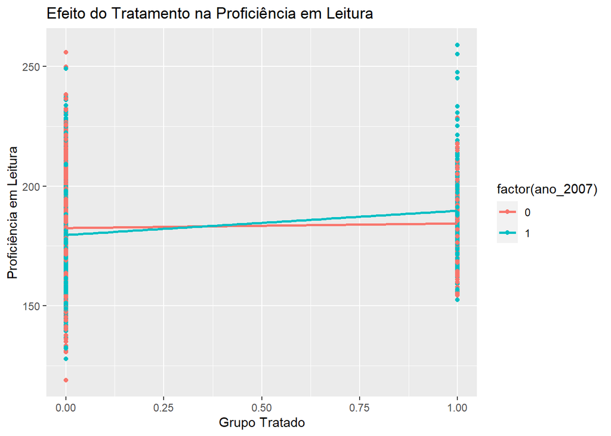

```r
library(ggplot2)

# Gráfico de Dispersão para Leitura
ggplot(data, aes(x = grupo_tratado, y = profic_port, color = factor(ano_2007))) +
  geom_point() +
  geom_smooth(method = "lm", se = FALSE) +
  labs(title = "Efeito do Tratamento na Proficiência em Leitura",
       x = "Grupo Tratado",
       y = "Proficiência em Leitura")
```

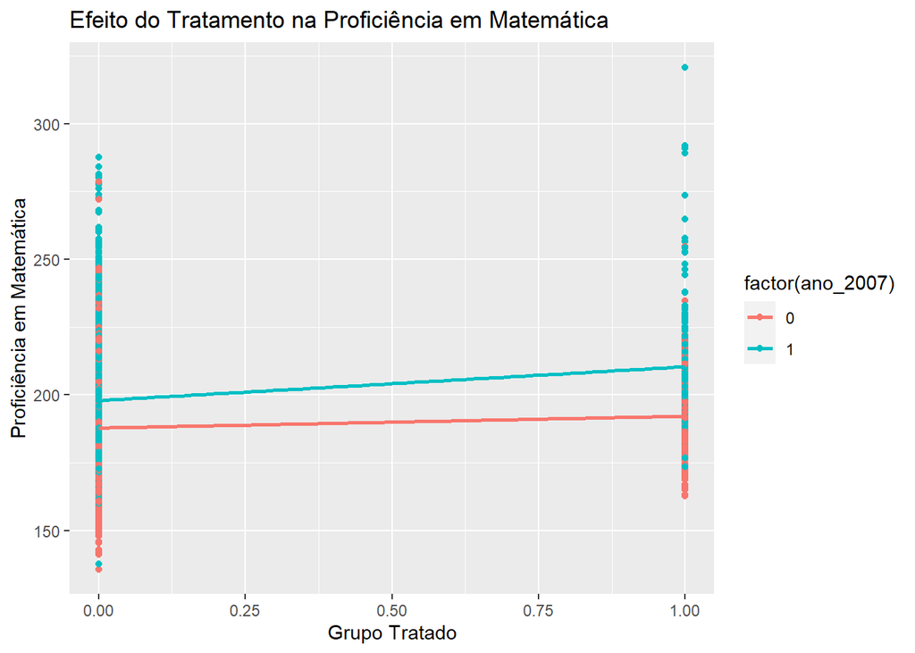

```r
# Gráfico de Dispersão para Matemática
ggplot(data, aes(x = grupo_tratado, y = profic_mat, color = factor(ano_2007))) +
  geom_point() +
  geom_smooth(method = "lm", se = FALSE) +
  labs(title = "Efeito do Tratamento na Proficiência em Matemática",
       x = "Grupo Tratado",
       y = "Proficiência em Matemática")
```

Os gráficos de dispersão para leitura e matemática destacam visualmente o impacto do tratamento em escolas públicas. No gráfico de leitura, a diferenciação entre os grupos tratado e de controle é evidente, indicando uma possível influência positiva do tratamento.

A linha de regressão, apontando para cima, sugere um efeito médio favorável. Similarmente, o gráfico de matemática revela uma diferenciação entre os grupos, com a linha de regressão indicando uma diferença média positiva no desempenho entre os grupos.

Esses gráficos, embora preliminares, fornecem uma visão intuitiva do potencial impacto do programa na proficiência dos alunos.

## Estimação por Efeitos Fixos

### Proeficiência em Leitura

```r
plm(profic_port ~ tratamento + ano_2007, model = c("within"), data = data) %>% summary()
```

```
## Oneway (individual) effect Within Model
##
## Call:
## plm(formula = profic_port ~ tratamento + ano_2007, data = data,
##     model = c("within"))
##
## Unbalanced Panel: n = 2, T = 3716-3716, N = 7432
##
## Residuals:
##      Min.   1st Qu.    Median   3rd Qu.      Max.
## -63.58831 -11.59053  -0.92947  10.80726  73.17937
##
## Coefficients:
##            Estimate Std. Error t-value  Pr(>|t|)
## tratamento  10.1100     1.2222  8.2721 < 2.2e-16 ***
## ---
## Signif. codes:  0 '***' 0.001 '**' 0.01 '*' 0.05 '.' 0.1 ' ' 1
##
## Total Sum of Squares:    1998900
## Residual Sum of Squares: 1980600
## R-Squared:      0.0091269
## Adj. R-Squared: 0.0088602
## F-statistic: 68.4285 on 1 and 7429 DF, p-value: < 2.22e-16
```

- **Efeito do Tratamento:** `10.1100`

O modelo de efeitos fixos também controla para efeitos fixos individuais, enquanto o modelo de regressão linear pode incluir outras variáveis que não foram especificadas aqui.

### Proeficiência em Matemática

- **Efeito do Tratamento:** `12.4707`

```r
plm(profic_mat ~ tratamento + ano_2007, model = c("within"), data = data) %>% summary()
```

```
## Oneway (individual) effect Within Model
##
## Call:
## plm(formula = profic_mat ~ tratamento + ano_2007, data = data,
##     model = c("within"))
##
## Unbalanced Panel: n = 2, T = 3716-3716, N = 7432
##
## Residuals:
##     Min.  1st Qu.   Median  3rd Qu.     Max.
## -60.4537 -12.1687  -1.5252  10.9487 110.4655
##
## Coefficients:
##            Estimate Std. Error t-value  Pr(>|t|)
## tratamento  12.4707     1.3033  9.5685 < 2.2e-16 ***
## ---
## Signif. codes:  0 '***' 0.001 '**' 0.01 '*' 0.05 '.' 0.1 ' ' 1
##
## Total Sum of Squares:    2280100
## Residual Sum of Squares: 2252300
## R-Squared:      0.012174
## Adj. R-Squared: 0.011908
## F-statistic: 91.5565 on 1 and 7429 DF, p-value: < 2.22e-16
```

Portanto, os resultados diferentes podem ser devidos às diferenças nas especificações dos modelos, principalmente na inclusão de termos para o ano de 2007 e a interação tratamento * ano 2007 no modelo de regressão linear. Além disso, a inclusão de efeitos fixos individuais no modelo de efeitos fixos pode estar impactando a estimativa do efeito do tratamento.

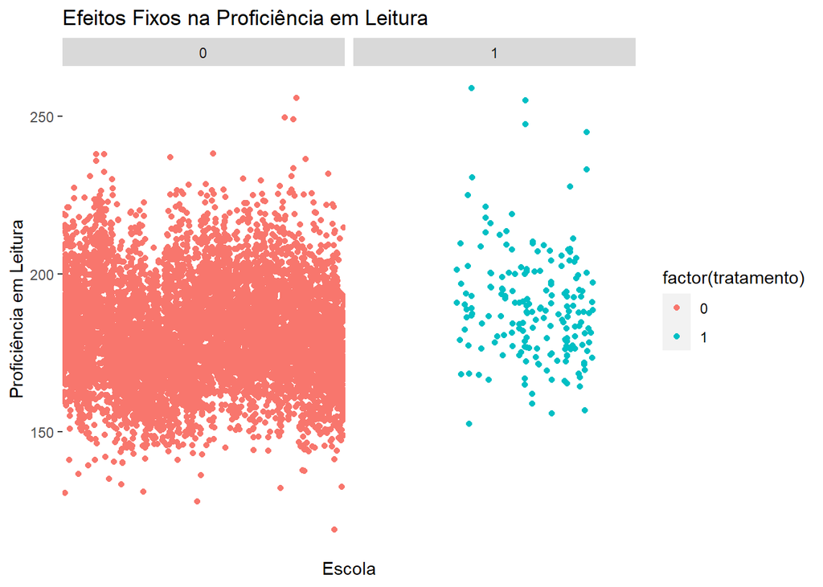

```r
# Gráfico de Dispersão com Efeitos Fixos para Leitura
ggplot(data, aes(x = factor(escola), y = profic_port, color = factor(tratamento))) +
  geom_point() +
  labs(title = "Efeitos Fixos na Proficiência em Leitura",
       x = "Escola",
       y = "Proficiência em Leitura") +
  theme(axis.text.x = element_blank(), axis.ticks.x = element_blank()) +
  facet_wrap(~tratamento)
```

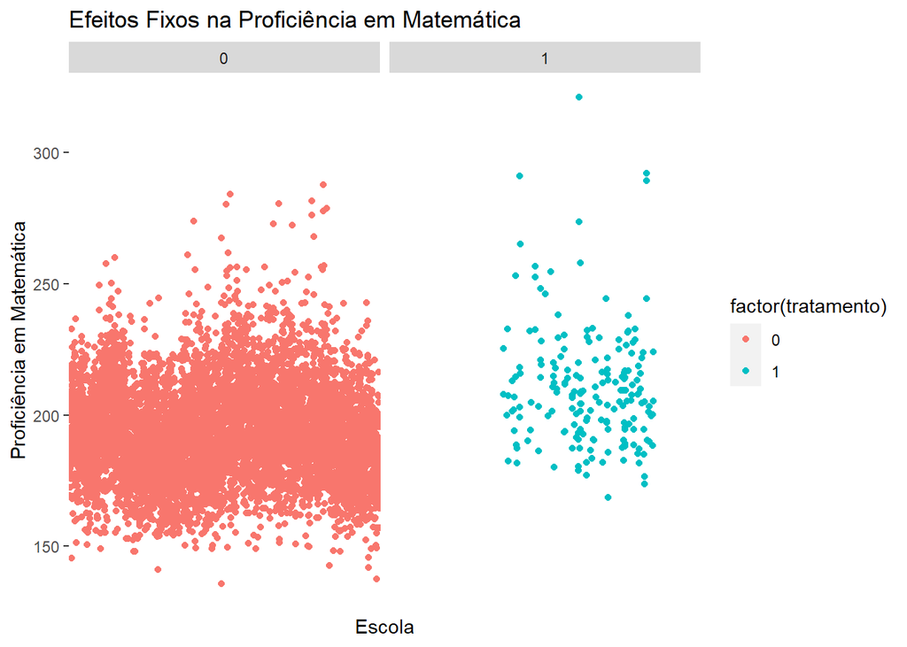

```r
# Gráfico de Dispersão com Efeitos Fixos para Matemática
ggplot(data, aes(x = factor(escola), y = profic_mat, color = factor(tratamento))) +
  geom_point() +
  labs(title = "Efeitos Fixos na Proficiência em Matemática",
       x = "Escola",
       y = "Proficiência em Matemática") +
  theme(axis.text.x = element_blank(), axis.ticks.x = element_blank()) +
  facet_wrap(~tratamento)
```

## Primeiras Diferenças

Ao utilizar o método de primeiras diferenças, transformamos os dados de painel ao subtrair os valores individuais no tempo t pelos valores no tempo t−1. Isso tem o efeito de eliminar os efeitos fixos individuais, tornando o modelo mais robusto contra variáveis não observadas que são constantes ao longo do tempo para cada indivíduo ou unidade de painel.

### Proeficiência em Leitura

```r
plm(profic_port ~ tratamento + ano_2007, model = c("fd"), data = data) %>% summary()
```

```
## Oneway (individual) effect First-Difference Model
##
## Call:
## plm(formula = profic_port ~ tratamento + ano_2007, data = data,
##     model = c("fd"))
##
## Unbalanced Panel: n = 2, T = 3716-3716, N = 7432
## Observations used in estimation: 7430
##
## Residuals:
##      Min.   1st Qu.    Median   3rd Qu.      Max.
## -85.48907 -12.66935  -0.12713  12.98247  81.18289
##
## Coefficients:
##               Estimate Std. Error t-value Pr(>|t|)
## (Intercept) -0.0019625  0.2332650 -0.0084 0.993288
## tratamento   4.0625507  1.3434451  3.0240 0.002503 **
## ---
## Signif. codes:  0 '***' 0.001 '**' 0.01 '*' 0.05 '.' 0.1 ' ' 1
##
## Total Sum of Squares:    3006700
## Residual Sum of Squares: 3003000
## R-Squared:      0.0012296
## Adj. R-Squared: 0.0010951
## F-statistic: 9.14445 on 1 and 7428 DF, p-value: 0.0025033
```

- **Efeito do Tratamento:** `4.0625507`

É estatisticamente significativo, indicando que há evidência para sugerir que o tratamento teve um impacto significativo na proficiência em leitura.

### Proeficiência em Matemática

```r
plm(profic_mat ~ tratamento + ano_2007, model = c("fd"), data = data) %>% summary()
```

```
## Oneway (individual) effect First-Difference Model
##
## Call:
## plm(formula = profic_mat ~ tratamento + ano_2007, data = data,
##     model = c("fd"))
##
## Unbalanced Panel: n = 2, T = 3716-3716, N = 7432
## Observations used in estimation: 7430
##
## Residuals:
##      Min.   1st Qu.    Median   3rd Qu.      Max.
## -107.0303  -13.2102    0.2202   13.4219   98.4254
##
## Coefficients:
##             Estimate Std. Error t-value  Pr(>|t|)
## (Intercept)  0.00178    0.24461  0.0073 0.9941942
## tratamento   5.19078    1.40877  3.6846 0.0002307 ***
## ---
## Signif. codes:  0 '***' 0.001 '**' 0.01 '*' 0.05 '.' 0.1 ' ' 1
##
## Total Sum of Squares:    3308200
## Residual Sum of Squares: 3302200
## R-Squared:      0.0018244
## Adj. R-Squared: 0.00169
## F-statistic: 13.5764 on 1 and 7428 DF, p-value: 0.00023068
```

- **Efeito do Tratamento:** `5.19078`

É estatisticamente significativo, indicando que há evidência para sugerir que o tratamento teve um impacto significativo na proficiência em matemática.

Assim como no caso do modelo de leitura, a escolha do método pode impactar os resultados. O método de primeiras diferenças é robusto contra efeitos fixos individuais, mas ainda pode haver outras diferenças na especificação do modelo que influenciam os resultados.

- **Analisando hipoteticamente para 2003**

Suponha que tivéssemos dados para o ano de 2003. Adicionando dados desse ano ao nosso banco e, na primeira equação, inseríssemos uma dummy para o ano de 2005 e a interação desta com `grupo_tratado_i`, qual seria a interpretação de um coeficiente `β₀ = 10` com erro-padrão, s.e.`(β) = 3`?

## Conclusão

O presente trabalho buscou analisar o impacto de um programa de distribuição de material didático em escolas públicas, implementado em 2006, sobre a proficiência média em leitura e matemática. Utilizando uma abordagem de DiD (Diferenças em Diferenças), OLS (Mínimos Quadrados Ordinários), e métodos de efeitos fixos e primeiras diferenças, exploramos diferentes perspectivas para entender os efeitos do tratamento.